# ExpoApp Quality Data Analysis

David Donaire-Gonzalez

## Phone & ExpoApp Settings

Android Version: 8.1.0  
ExpoApp Version: 1.0.3  
IMEI: 358340081122127  
Device manufacturer: samsung  
Device model: SM-J530Y  
Application settings:  
ID: ddg  
Encryption used: RSA2  
Session start date: Mon Jan 13 13 44 16 GMT+11 00 2020  
Sensor: ACC ON - 30 hz  
Sensor: GPS ON - 1 sec - Asymmetric encryption  
Sensor: BAR OFF  
Sensor: HR OFF  
Sensor: IL OFF  
Sensor: UI ON - 1 sec

## Evaluation of Data Completeness:

Recorded, Wearing, and with All, GPS and NETWORK location

| Type | 2020-01-13 | 2020-01-14 | 2020-01-15 |
| --- | --- | --- | --- |
| Recorded | 0.7 | 0.9 | 2.2 |
| Wearing | 0.7 | 0.9 | 2.2 |
| ALL_Location | 0.7 | 0.9 | 2.2 |
| GPS_Location | 0.7 | 0.8 | 1.2 |
| NET_Location | 0.0 | 0.1 | 1.0 |

## ExpoApp Physical Activity Plot

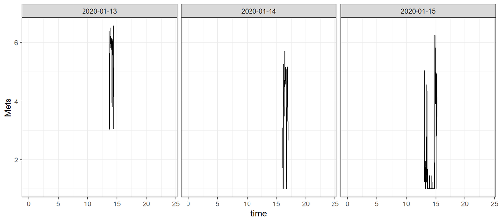

## ExpoApp Map

[interactive chart not shown]

## Minutes with accelerometer but no location

(off: smartphone turn off)

| day | 00 | 01 | 02 | 03 | 04 | 05 | 06 | 07 | 08 | 09 | 10 | 11 | 12 | 13 | 14 | 15 | 16 | 17 | 18 | 19 | 20 | 21 | 22 | 23 |
| --- | --- | --- | --- | --- | --- | --- | --- | --- | --- | --- | --- | --- | --- | --- | --- | --- | --- | --- | --- | --- | --- | --- | --- | --- |
| 2020-01-13 | - | - | - | - | - | - | - | - | - | - | - | - | - | 0 | 0 | off | off | off | off | off | off | off | off | off |
| 2020-01-14 | off | off | off | off | off | off | off | off | off | off | off | off | off | off | off | off | 0 | off | off | off | off | off | off | off |
| 2020-01-15 | off | off | off | off | off | off | off | off | off | off | off | off | off | 0 | 0 | 0 | - | - | - | - | - | - | - | - |

## ExpoApp logcat

Mon Jan 13 12:05:23 GMT+11:00 2020 - System power on  
Mon Jan 13 13:44:16 GMT+11:00 2020 - ExpoApp Started  
Mon Jan 13 14:25:08 GMT+11:00 2020 - Smartphone shutdown  
Tue Jan 14 16:03:32 GMT+11:00 2020 - System power on  
Tue Jan 14 16:04:43 GMT+11:00 2020 - ExpoApp Restarted  
Tue Jan 14 16:57:14 GMT+11:00 2020 - Smartphone shutdown  
Wed Jan 15 13:01:19 GMT+11:00 2020 - System power on  
Wed Jan 15 13:02:28 GMT+11:00 2020 - ExpoApp Restarted